# Pursuing Equity of Open Access Publishing in Bioarchaelogy

Author

Bjørn Peare Bartholdy

Abstract

Open Access (OA) allows anyone with a reliable internet connection to read scientific articles. While this democratises access to knowledge, there remains a disparity in production of knowledge, as the different paths to OA have widely different costs and impact. In most cases, the cost falls on university libraries as part of read-and-publish deals with scientific publishers. In other cases the cost may fall on authors in the form of Article Processing Charges.

In this study I use bibliographic data from OpenAlex on Bioarchaeology articles published between 1990 and 2024 (inclusive) to explore the impact of OA articles compared to closed articles using the calculated Field-weighted Citation Impact (FWCI).

Overall, OA articles have had a higher impact, with an estimated 30.1% increase in FWCI (90% CI[26.0%, 34.3%]) compared to closed articles. Green OA had the highest increase with 136% (90% CI[127%, 145%]) followed by Bronze (28%, 90% CI[21%, 36%]), Gold (19%, 90% CI[13%, 26%]), and Hybrid (15%, 90% CI[7%, 24%]). Diamond OA articles are associated with a decrease in FWCI (-51%, 90% CI[-61%, -42%]).

While Diamond OA is the most equitable model, it currently comes with a decrease in potential impact for authors. Those who have the luxury of choice can select the journal that will give their article the greatest potential impact, while others risk losing impact in order to make their articles accessible. Until this changes, scholarly publishing in Bioarchaeology is not truly equitable.

## Scientific publishing is broken

Publishing a journal article seems to have become the end goal of research, rather than the advancement of science. As a result (or as a possible cause), the publishing industry has become absurdly profitable. It has become the currency of academia, and often it is the quantity of articles that can make or break a researcher’s career, not the quality. This leaves no incentive to conduct rigorous science, especially when there is rarely a requirement to be transparent about the analyses. Fast science is leading to increasing amounts of research waste, and it is impossible for researchers to keep up.

It’s a legacy system that we need to leave behind, and something different needs to replace it (Chou 2025). Science is for stakeholders, not shareholders.

Many researchers have become fed up, as is evident from the mass resignations of editorial boards (Marcus and Oransky (2023)) and the anti-trust lawsuit filed against the so-called ‘Big Six’, Elsevier, John Wiley & Sons, Sage, Taylor & Francis, Springer, and Wolters Kluwer (DR. ELVISHA DHAMALA, DR. SHELLEY FACENTE, DR. ROBERT MAHON, and DR. LUCINA UDDIN, Plaintiffs, vs. ELSEVIER, B.V., INFORMA PLC, INTERNATIONAL ASSOCIATION OF SCIENTIFIC, TECHNICAL, AND MEDICAL PUBLISHERS, JOHN WILEY & SONS, INC., SAGE PUBLICATIONS, INC., SPRINGER NATURE AG & CO. KGaA., TAYLOR & FRANCIS GROUP, LLC, TAYLOR & FRANCIS GROUP, LTD., WOLTERS KLUWER HEALTH, INC., WOLTERS KLUWER N.V., and JOHN DOES 1 THROUGH 50, Defendants., n.d.).

## Absurdly profitable

Researchers do research, often funded by public money, write manuscripts, while funded by public money, review manuscripts, while employed by a university, only for the university, or the public money, to pay to publish the article in a journal (Buranyi 2017). If you want Open Access, then you may have to pay extra. It’s a fantastic business model. For the publishers. And no one else.

Until recently, the majority of research was stuck behind a paywall, despite being funded by public money (Figure 1).

## Open Access is inequitable

Open Access articles generally have a higher impact than closed articles. Even within OA articles, the type of OA matters (Figure 3).

Because of APCs, OA varies hugely in cost (Figure 2), which for many scholars means there are limited options for publishing their research (Cox 2023).

```r
# Data frame to create labels for the percentage of each OA status in 2024 (for stacked area plot)
oa_prop_labels <- articles_oa_data |>
    group_by(oa_status, publication_year) |>
    count() |>
    group_by(publication_year) |>
    arrange(factor(oa_status, levels = c("diamond", "green", "gold", "hybrid", "bronze", "closed")), .by_group = TRUE) |>
    mutate(
      prop_oa = n / sum(n),
      cum_prop = cumsum(prop_oa) # cumulative sum to position the labels next to status on the y-axis
    ) |>
    arrange(desc(publication_year))

perc_closed <- filter(oa_prop_labels, oa_status == "closed" & publication_year == 2024)$prop_oa
```

```r
# Stacked area plot of the proportion of each oa status per year
cumulative_oa_pl <- articles_oa_data |>
  group_by(oa_status, publication_year) |>
  count() |>
  group_by(publication_year) |>
  mutate(
    is_oa = ifelse(oa_status == "closed", "closed", "open"),
    prop_oa = n / sum(n)
  ) |>
  ggplot(aes(x = publication_year, y = n, fill = oa_status)) +
    geom_stream(type = "proportional", bw = 0.7, col = "white", alpha = 0.8) +
    geom_hline(yintercept = 0.25, linetype = "dotted", colour = "white") +
    geom_hline(yintercept = 0.50, linetype = "dotted", colour = "white") +
    geom_hline(yintercept = 0.75, linetype = "dotted", colour = "white") +
    annotate('text', size = 5, label = "25%", y = 0.28, x = 1992, colour = "white") +
    annotate('text', size = 5, label = "50%", y = 0.53, x = 2007, colour = "white") +
    annotate('text', size = 5, label = "75%", y = 0.78, x = 2022, colour = "white") +
    geom_text(
      data = filter(oa_prop_labels, publication_year == 2024),
      aes(y = cum_prop, label = scales::percent(prop_oa)),
      size = 3,
      nudge_x = 1.6,
      nudge_y = c(-0.05, 0, -0.1, -0.1, -0.05, -0.2) # specific values for each oa_status
    ) +
    scale_fill_manual(values = oa_palette) +
    theme_void() +
    theme(
      axis.text.x = element_text(vjust = 4, size = 8),
      axis.title.x = element_text(hjust = 0.91, vjust = 2, size = 10),
      legend.position = c(0.26, 0.84),
      legend.direction = "horizontal",
      legend.text = element_text(colour = "white", size = 5),
      legend.title = element_text(colour = "white", size = 7),
      legend.key.size = unit(5, "mm"),
      plot.margin = margin(8, 6, 6, 6),
      plot.title = element_text(family = "Atkinson Hyperlegible"),
      plot.subtitle = element_text(family = "Atkinson Hyperlegible", size = 8)
    ) +
    labs(
      x = "Publication year",
      fill = "OA Model",
      title = bquote(.(scales::percent(perc_closed)) ~ "of bioarchaeological articles still stuck behind a" ~ bold("paywall")),
      subtitle = stringr::str_wrap("Even when the research is publicly funded, articles can end up behindand be inaccessible, not only to the public, but also universities, other institutions, and independent scholars that can't afford to make a deals with publishers. Until recently this was the majority of articles.", width = 120)
    )

ggsave(here::here("outputs/BABAO2025/figures/BABAO_cumulative-oa.png"), cumulative_oa_pl, width = 150, height = 110, units = "mm")
```

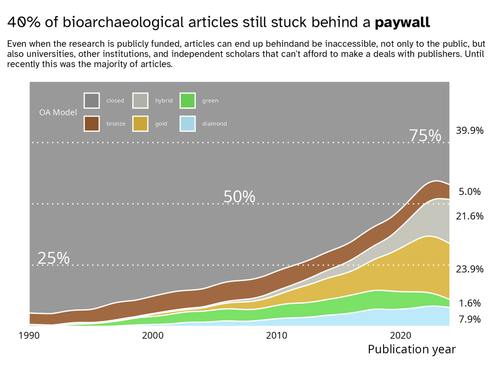

Figure 1: Cumulative stream plot of the percentage of Open Access Bioarchaeology articles between 1990 and 2024.

```r
location_counts_pl <- common_journals |>
  arrange(desc(n)) |>
  slice_head(n = 15) |>
    ggplot(aes(x = reorder(primary_location, n), y = n)) +
      geom_col(aes(fill = primary_location_org), width = 0.6) +
      geom_text(
        aes(label = paste0("$", apc_usd)),
        size = 3.7, colour = "white",
        hjust = 1, nudge_y = -8,
        family = "Atkinson Hyperlegible",
        fontface = "bold"
      ) +
      scale_fill_viridis_d(end = 0.9) +
      coord_flip() +
      theme_minimal() +
      labs(
        fill = "Publisher",
        title = "Article processing charges (APCs)",
        subtitle = bquote("While" ~ bold("democratising access to research,") ~ "the APC model has created" ~ bold("inequity in contributions to research.")),
        y = "Article count"
      ) +
      theme(
        legend.position = c(0.82, 0.26),
        legend.text = element_text(size = 5),
        legend.title = element_text(hjust = 0.5, size = 7),
        legend.key.size = unit(5, "mm"),
        panel.grid.major.y = element_blank(),
        plot.title = element_text(hjust = -1.27, family = "Atkinson Hyperlegible", size = 14),
        plot.subtitle = element_text(hjust = 1.1, size = 10, family = "Atkinson Hyperlegible"),
        axis.title.y = element_blank(),
        axis.text.y = element_text(margin = margin(r = -10), size = 8),
        axis.title.x = element_text(hjust = 1)
      )

ggsave(here::here("outputs/BABAO2025/figures/BABAO_location-counts.png"), location_counts_pl, width = 180, height = 100, units = "mm")
```

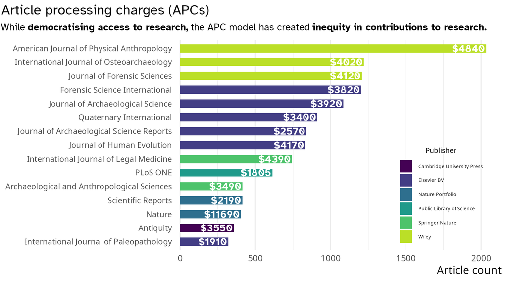

Figure 2: The journals in which most Bioarchaeological research is published. Includes total article count (x-axis), name of the journal (y-axis), APC in US Dollars, and publisher (colour of bars).

```r
oa_advantage_pl <- fwci_status_df |>
  mutate(perc_diff = prop_diff * 100) |>
  ggplot(aes(x = perc_diff, y = reorder(oa_status, perc_diff))) +
    geom_point(aes(col = oa_status, shape = oa_status, fill = oa_status), size = 4) +
    geom_linerange(aes(xmin = lower_ci * 100, xmax = upper_ci * 100, col = oa_status), show.legend = F, linewidth = 1.2) +
    #geom_pointrange(aes(xmin = lower_ci * 100, xmax = upper_ci * 100, col = oa_status, shape = oa_status),show.legend = F, size = 1.2, linewidth = 1.2) +
    geom_vline(xintercept = 0, linewidth = 1.6, colour = "grey50") +

    annotate(
      geom = "text",
      label = "Relative to\nclosed access",
      x = -30,
      y = 5.2,
      size = 3,
      color = "black",
      family = "Atkinson Hyperlegible"
    ) +
    geom_curve(
      mapping = aes(
        x = -16,
        xend = -4,
        y = 5.2,
        yend = 5.1
      ),
      color = "grey20",
      curvature = -0.2,
      linewidth = 0.3,
      arrow = arrow(length = unit(0.08, "in"))
    ) +

    scale_colour_manual(values = oa_palette, breaks = c("green", "bronze", "gold", "hybrid", "diamond")) +
    scale_fill_manual(values = oa_palette, breaks = c("green", "bronze", "gold", "hybrid", "diamond")) +
    scale_shape_manual(values = c(15,19,17,25,23), breaks = c("green", "bronze", "gold", "hybrid", "diamond")) +
    labs(
      x = "Change in Field-Weighted Citation Impact (%)",
      col = "OA Model",
      shape = "OA Model",
      fill = "OA Model",
      title = bquote(bold("Open Access Citation Advantage") ~ "fosters a ‘pay to win’-like system"),
      subtitle = stringr::str_wrap("APCs combined with the OA citation advantage have created further inequity in publishing since the costly OA models (bronze, gold, hybrid) provide an advantage over more equitable models like diamond.", width = 114)
    ) +
    theme_minimal() +
    theme(
      panel.grid.major.y = element_blank(),
      axis.title.x = element_text(hjust = 0.99, vjust = 1),
      axis.line.x = element_line(color = "grey90", linewidth = 0.8, arrow = grid::arrow(length = unit(3, "mm"))),
      axis.text.y = element_blank(),
      axis.title.y = element_blank(),
      plot.subtitle = element_text(vjust = 3, family = "Atkinson Hyperlegible", size = 10),
      plot.title = element_text(vjust = 3, family = "Atkinson Hyperlegible", size = 14),
      plot.margin = margin(b = 1, t = 16),
      legend.position = c(0.92, 0.22),
      legend.text = element_text(size = 7),
      legend.title = element_text(size = 9)
    )

ggsave(here::here("outputs/BABAO2025/figures/BABAO_oa-citation-advantage.png"), oa_advantage_pl, width = 176, height = 120, units = "mm")
```

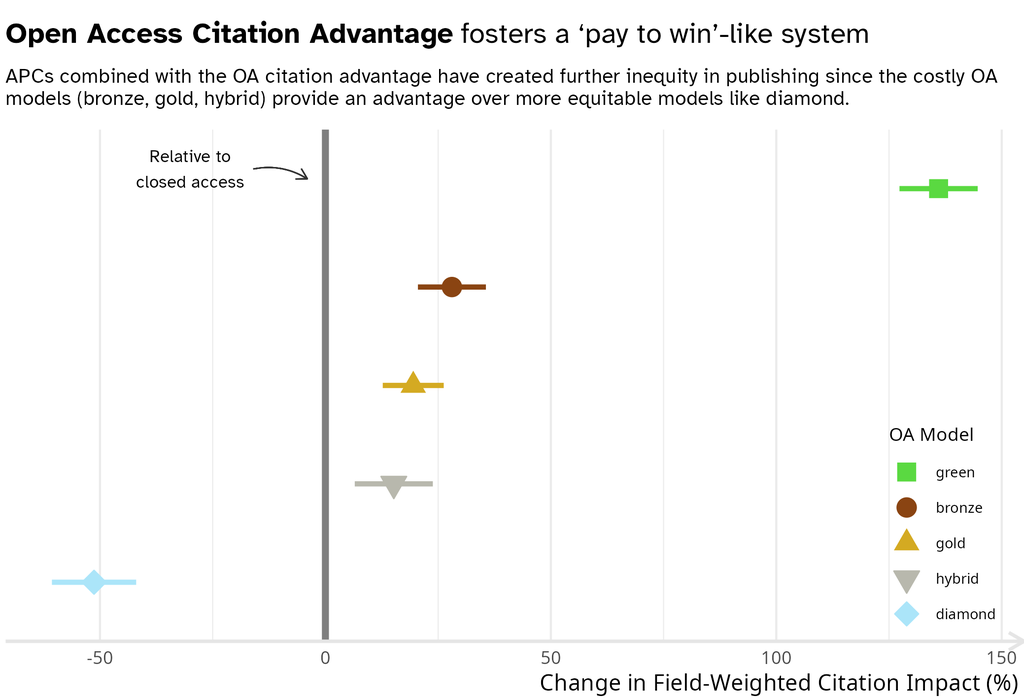

Figure 3: Plot of the citation advantage/disadvantage (represented as FWCI) of Open Access models compared to closed (solid grey line at 0). Bars represent the 90% confidence intervals.

## Publishers undermine academic freedom

The use of bundled deals and subscriptions with publishing companies that allow authors to publish in journals for free (or at a reduced cost) influences where researchers may choose to publish their work, and undermines academic freedom. If the author is of a paper affiliated with an institution with a limited budget, that choice may be all but eliminated (Aspesi and Brand 2020).

Since 1990, 42% of all bioarchaeological articles have been published with the six largest publishers.

Some publishers are branching out into scientific metrics and analytics, and selling those services to the universities, which puts publishers in control of both the researchers’ outputs and the valuation of those outputs, essentially putting careers in their hands. It also means they can potentially undermine the value of journal offered by competing publishers (Aspesi and Brand 2020).

## The publishing industry is bad for science

Researchers are incentivised to publish novel, controversial topics, not quality.

The single submission rule combined with the ‘gag rule’ (DR. ELVISHA DHAMALA, DR. SHELLEY FACENTE, DR. ROBERT MAHON, and DR. LUCINA UDDIN, Plaintiffs, vs. ELSEVIER, B.V., INFORMA PLC, INTERNATIONAL ASSOCIATION OF SCIENTIFIC, TECHNICAL, AND MEDICAL PUBLISHERS, JOHN WILEY & SONS, INC., SAGE PUBLICATIONS, INC., SPRINGER NATURE AG & CO. KGaA., TAYLOR & FRANCIS GROUP, LLC, TAYLOR & FRANCIS GROUP, LTD., WOLTERS KLUWER HEALTH, INC., WOLTERS KLUWER N.V., and JOHN DOES 1 THROUGH 50, Defendants., n.d.) and a slow reviewer turnaround, slows scientific advancement since results from research can take months or even years to reach publication. This is also bad for early career researchers who are on the job market or PhD candidates who need to defend within a specific timeline.

All the actual scientific discussion around the evaluation of a publication is done behind closed doors (so to speak), with very little actual discussion between authors and reviewers, and the wider scientific community have no way of seeing what issues and concerns were brought up or addressed during this psuedo-discussion. This model facilitates gatekeeping and allows reviewers to potentially hold up a review if they happen to have a similar study that they want to publish first.

‘Prestige’ is tied to journals rather than the output itself. If the journal doesn’t think the content of an article is novel, controversial, or ‘sexy’ enough, they may choose not to publish it. Replication studies are an essential part of science, but are rarely ‘sexy’, controversial, and, by definition, are not novel.

## What can you do?

The research should be its own stamp of quality not the journal that published it.

- Make your work reproducible
- Facilitate replication of your work (and replicate others’)
- Emphasize importance of other outputs (data, methods, etc.)
- Publish with journals doing open peer-review

The publishing industry has no incentive to change their practices. They are companies doing company things and have shareholders to please.

- Stop using journals owned by the large publishers
- Refuse to publish, review, and do editorial work

The cost of publishing an article should be decided by the cost of producing it, not some arbitrary, opaque process.

- What exactly does Springer offer when charging >$11000 to publish your article?

Support community-led publishing

- Submit good articles to Diamond OA journals (see https://diamond.open-archaeo.info; Batist et al. (2025))
- focus editorial and reviewer work on not-for-profit journals

## Methods

Here I focus on published articles in Human Bioarchaeology, defined by Buikstra and Colleagues (2022) as “the study of human remains from Holocene archaeological and historical contexts” and includes paleopathology.

The OpenAlex (Priem, Piwowar, and Orr 2022) database was accessed on 2025-05-09 using the API through the openalexR R package (Massimo et al. 2024). Only articles were retrieved, and were further filtered by the topics ‘Forensic Anthropology and Bioarchaeology Studies (T10992)’ and ‘Paleopathology and ancient diseases (T13409)’. This means that only works containing these topics (each work is assigned up to three topics) were retrieved. Works were further limited to including the following as primary topics:

- Forensic Anthropology and Bioarchaeology Studies (T10992)
- Paleopathology and ancient diseases (T13409)
- Pleistocene-Era Hominins and Archaeology
- Forensic and Genetic Research
- Archaeology and ancient environmental studies
- Dental Radiography and Imaging
- Morphological variations and asymmetry

Open Access model definitions follow OpenAlex (Table 1).

Percent changes in FWCI with associated 90% confidence intervals were obtained from a linear regression with FWCI as the continuous response variable and OA status as the categorical predictor variable.

[figure not shown]

[Image by Esther Plomp](https://doi.org/10.5281/zenodo.12645766)

Table 1: Definitions of Open Access status used in this study, as defined by OpenAlex.

| Model | Definition |
| --- | --- |
| Closed | Not Open Access |
| Bronze | Open Access article with no identifiable license (unclear terms of re-use) |
| Hybrid | Open Access article in a subscription journal. Open Access obtained by paying an APC. |
| Gold | Open Access article in a fully Open Access journal. Open Access obtained by paying an APC. |
| Diamond | Open Access article in a fully Open Access journal that does not charge an APC. |
| Green | Closed access article in a journal, but an Open Access version of the article exists elsewhere (e.g., institutional repository or preprint server) |

## References

Aspesi, Claudio, and Amy Brand. 2020. “In Pursuit of Open Science, Open Access Is Not Enough.” *Science* 368 (6491): 574–77. https://doi.org/10.1126/science.aba3763.

Batist, Zack, N Frerebeau, Andrea Titolo, Joe Roe, Bjørn Peare Bartholdy, and Petr Pajdla. 2025. “Diamond Archaeology.” Zenodo. https://doi.org/10.5281/ZENODO.15026608.

Buikstra, Jane E., Sharon N. DeWitte, Sabrina C. Agarwal, Brenda J. Baker, Eric J. Bartelink, Elizabeth Berger, Kelly E. Blevins, et al. 2022. “Twenty-First Century Bioarchaeology: Taking Stock and Moving Forward.” *American Journal of Biological Anthropology* 178 (S74): 54–114. https://doi.org/10.1002/ajpa.24494.

Buranyi, Stephen. 2017. “Is the Staggeringly Profitable Business of Scientific Publishing Bad for Science?” *The Guardian: Science*, June 27, 2017. https://www.theguardian.com/science/2017/jun/27/profitable-business-scientific-publishing-bad-for-science.

Chou, Seemay. 2025. “Scientific Publishing: Enough Is Enough.” Substack newsletter. Human Readable. June 2, 2025. https://asterainstitute.substack.com/p/scientific-publishing-enough-is-enough.

Cox, Emily. 2023. “Research Outputs as Testimony &Amp; the APC as Testimonial Injustice in the Global South.” *College & Research Libraries* 84 (4, 4): 513. https://doi.org/10.5860/crl.84.4.513.

DR. ELVISHA DHAMALA, DR. SHELLEY FACENTE, DR. ROBERT MAHON, and DR. LUCINA UDDIN, Plaintiffs, vs. ELSEVIER, B.V., INFORMA PLC, INTERNATIONAL ASSOCIATION OF SCIENTIFIC, TECHNICAL, AND MEDICAL PUBLISHERS, JOHN WILEY & SONS, INC., SAGE PUBLICATIONS, INC., SPRINGER NATURE AG & CO. KGaA., TAYLOR & FRANCIS GROUP, LLC, TAYLOR & FRANCIS GROUP, LTD., WOLTERS KLUWER HEALTH, INC., WOLTERS KLUWER N.V., and JOHN DOES 1 THROUGH 50, Defendants. n.d.

Marcus, Adam, and Ivan Oransky. 2023. “The Retraction Watch Mass Resignations List.” Retraction Watch. September 28, 2023. https://retractionwatch.com/the-retraction-watch-mass-resignations-list/.

Massimo, Aria, Le Trang, Cuccurullo Corrado, Belfiore Alessandra, and Choe June. 2024. “openalexR: An r-Tool for Collecting Bibliometric Data from OpenAlex.” *The R Journal* 15 (4): 167–80. https://doi.org/10.32614/RJ-2023-089.

Priem, Jason, Heather Piwowar, and Richard Orr. 2022. “OpenAlex: A Fully-Open Index of Scholarly Works, Authors, Venues, Institutions, and Concepts.” June 17, 2022. https://doi.org/10.48550/arXiv.2205.01833.